# Examination of the Effectiveness of BMI as a Health Metric

# 1 Setup and Data Ingest

The following section covers the loading of the `libraries`, scripts and data necessary to complete this study.

## 1.1 Initial Setup and Package Loads in R

The `libraries` and scripts necessary to complete this analysis are loaded using the code below:

```r
library(knitr)
library(rmdformats)
library(rmarkdown)
library(GGally)
library(patchwork)
library(car)
library(equatiomatic)
library(janitor)
library(magrittr)
library(mosaic)
library(naniar)
library(simputation)
library(broom)
library(nhanesA)
library(tidyverse)

## Global options

opts_chunk$set(comment=NA)
opts_knit$set(width=75)

theme_set(theme_bw())
options(dplyr.summarise.inform = FALSE)
```

## 1.2 Loading the Raw Data into R

The following code downloads the relevant 2017-2018 NHANES datasets, saves them locally to the `data` sub directory, and then loads these local copies into RStudio for use in this study:

```r
DEMO_J_raw <- nhanes('DEMO_J') %>% tibble()
```

```
Processing SAS dataset DEMO_J    ..
```

```r
BMX_J_raw <- nhanes('BMX_J') %>% tibble()
```

```
Processing SAS dataset BMX_J     ..
```

```r
TCHOL_J_raw <- nhanes('TCHOL_J') %>% tibble()
```

```
Processing SAS dataset TCHOL_J   ..
```

```r
TRIGLY_J_raw <- nhanes('TRIGLY_J') %>% tibble()
```

```
Processing SAS dataset TRIGLY_J      ..
```

```r
HDL_J_raw <- nhanes('HDL_J') %>% tibble()
```

```
Processing SAS dataset HDL_J     ..
```

```r
DBQ_J_raw <- nhanes('DBQ_J') %>% tibble()
```

```
Processing SAS dataset DBQ_J     ..
```

```r
saveRDS(DEMO_J_raw, "data/DEMO_J.Rds")
saveRDS(BMX_J_raw, "data/BMX_J.Rds")
saveRDS(TCHOL_J_raw, "data/TCHOL_J.Rds")
saveRDS(TRIGLY_J_raw, "data/TRIGLY_J.Rds")
saveRDS(HDL_J_raw, "data/HDL_J.Rds")
saveRDS(DBQ_J_raw, "data/DBQ_J.Rds")


DEMO_J_raw <- readRDS("data/DEMO_J.Rds")
BMX_J_raw <- readRDS("data/BMX_J.Rds")
TCHOL_J_raw <- readRDS("data/TCHOL_J.Rds")
TRIGLY_J_raw <- readRDS("data/TRIGLY_J.Rds")
HDL_J_raw <- readRDS("data/HDL_J.Rds")
DBQ_J_raw <- readRDS("data/DBQ_J.Rds")
```

# 2 Cleaning the Data

The following code creates new data sets by selecting for and filtering the necessary variables for the completion of Study 2 from the imported data sets above:

```r
DEMO_J_data = DEMO_J_raw %>%
  select(c(SEQN, RIDSTATR, RIDAGEYR)) %>%
  filter(RIDSTATR == 2) %>%
  filter(RIDAGEYR != ".") %>%
  filter(RIDAGEYR <= 79) %>%
  filter(RIDAGEYR >= 18) %>%
  mutate(SEQN = as.numeric(SEQN)) %>%
  mutate(RIDAGEYR = as.numeric(RIDAGEYR))

BMX_J_data = BMX_J_raw %>%
  select(c(SEQN, BMXBMI, BMXWAIST)) %>%
  filter(BMXBMI != ".") %>%
  filter(BMXWAIST != ".") %>%
  mutate(SEQN = as.numeric(SEQN)) %>%
  mutate(BMXBMI = round(as.numeric(BMXBMI), digits = 1)) %>%
  mutate(BMXWAIST = round(as.numeric(BMXWAIST), digits = 1))

TCHOL_J_data = TCHOL_J_raw %>%
  select(c(SEQN, LBXTC)) %>%
  filter(LBXTC != ".") %>%
  mutate(SEQN = as.numeric(SEQN)) %>%
  mutate(LBXTC = round(as.numeric(LBXTC), digits = 0))

TRIGLY_J_data = TRIGLY_J_raw %>%
  select(c(SEQN, LBXTR)) %>%
  filter(LBXTR != ".") %>%
  mutate(SEQN = as.numeric(SEQN)) %>%
  mutate(LBXTR = round(as.numeric(LBXTR), digits = 0))

HDL_J_data = HDL_J_raw %>%
  select(c(SEQN, LBDHDD)) %>%
  filter(LBDHDD != ".") %>%
  mutate(SEQN = as.numeric(SEQN)) %>%
  mutate(LBDHDD = round(as.numeric(LBDHDD), digits = 0))

DBQ_J_data = DBQ_J_raw %>%
  select(c(SEQN, DBQ700)) %>%
  filter(DBQ700 != ".") %>%
  filter(DBQ700 != 7) %>%
  filter(DBQ700 != 9) %>%
  mutate(SEQN = as.numeric(SEQN)) %>%
  mutate(DBQ700 = fct_recode(as.factor(DBQ700),
                             "Excellent" = "1",
                             "Very Good" = "2",
                             "Good" = "3",
                             "Fair" = "4",
                             "Poor" = "5"))
```

Additionally, the code above also converts all the selected and filtered variables to their appropriate format, rounding to the appropriate number of decimal places and defining the factor levels for the variables included in this study.

## 2.1 Merging the Data

The following code merges the altered data sets above to create the complete case dataset that will be used for this study:

```r
study_2 = inner_join(inner_join(inner_join(inner_join(inner_join(DEMO_J_data, BMX_J_data, by = "SEQN"), TCHOL_J_data, by = "SEQN"), TRIGLY_J_data, by = "SEQN"), HDL_J_data, by = "SEQN"), DBQ_J_data, by = "SEQN") %>%
  clean_names()
```

## 2.2 The Raw Data

In this data set compiled for this study, called `study_2`, complete data on 9 variables across 2215 adult subjects was gathered, and have been briefly explained below:

- The subjects sequence number (`seqn`)
- baseline information on their age (`ridageyr`),
- their interview/examination status (`ridstatr`),
- their body-mass index (kg/m^**) (`bmxbmi`)
- their waist circumference (cm) (`bmxwaist`),
- their total cholesterol (mg/dL) (`lbxtc`),
- Triglyceride (mg/dL) (`lbxtr`),
- their direct HDL-Cholesterol (mg/dL) (`lbdhdd`), and
- how healthy is their diet (`dbq700`)

```r
glimpse(study_2)
```

```
Rows: 2,215
Columns: 9
$ seqn     <dbl> 93708, 93711, 93717, 93718, 93721, 93722, 93731, 93735, 93738~
$ ridstatr <labelled> 2, 2, 2, 2, 2, 2, 2, 2, 2, 2, 2, 2, 2, 2, 2, 2, 2, 2, 2,~
$ ridageyr <dbl> 66, 56, 22, 45, 60, 60, 20, 52, 26, 72, 73, 26, 63, 55, 60, 5~
$ bmxbmi   <dbl> 23.7, 21.3, 24.5, 22.0, 35.9, 23.8, 27.6, 35.1, 33.7, 33.9, 2~
$ bmxwaist <dbl> 88.2, 86.6, 86.2, 77.5, 113.2, 89.7, 101.7, 104.6, 102.7, 115~
$ lbxtc    <dbl> 209, 238, 213, 152, 122, 184, 153, 121, 146, 160, 262, 182, 2~
$ lbxtr    <dbl> 58, 48, 102, 46, 79, 54, 78, 116, 79, 105, 184, 63, 172, 213,~
$ lbdhdd   <dbl> 88, 72, 53, 63, 45, 78, 40, 42, 41, 48, 60, 48, 48, 49, 34, 4~
$ dbq700   <fct> Excellent, Very Good, Very Good, Good, Good, Excellent, Fair,~
```

Using the `glimpse()` function above shows a bit of our tibble, and each of our nine variables will be used as follows:

- the numeric variable called `seqn` not to be used in our model except for identification of subjects,
- our outcome variable will be `bmxbmi`, which as mentioned above describes body-mass index (kg/m<sup>2</sup>)
- our key predictor `lbxtc`, which describes participant total cholesterol level in mg/dL
- our three quantitative candidate predictors, specifically `lbxtr`, `lbdhdd` and `bmxwaist`, which describe triglyceride in mg/dL, direct HDL in mg/dL, and waist size in cm of the participants respectively
- our lone categorical candidate predictor, specifically `dbq700`, which describes the how the participants rated their diet’s health, and has been formatted into factor variable with appropriate levels in the first code chunk of this data cleaning section above

## 2.3 Which variables should be included in the tidy data set?

As we’ve already established, we will only be fitting the five predictors mentioned above - `lbxtc`, `lbxtr`, `lbdhdd`, `bmxwaist` and `dbq700` - to model our outcome `bmxbmi`. Seeing as we already filtered for complete cases and formatted our variables to the correct format above, the tidy data set `study_2` that we built earlier should be sufficient for our analysis.

## 2.4 Checking our Outcome and Key Predictor

The code below will first check the status of our outcome `bmxbmi` and our key predictor `lbxtc`:

```r
df_stats(~ bmxbmi + lbxtc, data = study_2)
```

| response | min | Q1 | median | Q3 | max | mean | sd | n | missing |
| --- | --- | --- | --- | --- | --- | --- | --- | --- | --- |
| bmxbmi | 15.5 | 24.5 | 28.3 | 33.6 | 65.3 | 29.6526 | 7.273613 | 2215 | 0 |
| lbxtc | 76.0 | 158.0 | 182.0 | 211.0 | 446.0 | 185.9598 | 41.629183 | 2215 | 0 |

The output above shows that we have 2215 samples, and that we have no missing values in either variable, so we should be good to go with them.

## 2.5 Checking the Quantitative Predictors

Besides `lbxtc` we have three other quantitative predictor candidates: `lbxtr`, `lbdhdd`. and `bmxwaist`

```r
df_stats(~ lbxtr + lbdhdd + bmxwaist, data = study_2)
```

| response | min | Q1 | median | Q3 | max | mean | sd | n | missing |
| --- | --- | --- | --- | --- | --- | --- | --- | --- | --- |
| lbxtr | 10.0 | 61.0 | 92.0 | 136 | 2684.0 | 112.88533 | 105.27373 | 2215 | 0 |
| lbdhdd | 11.0 | 42.0 | 50.0 | 61 | 178.0 | 53.20948 | 15.43200 | 2215 | 0 |
| bmxwaist | 63.2 | 87.2 | 98.5 | 111 | 169.5 | 99.98763 | 17.36016 | 2215 | 0 |

## 2.6 Checking the Categorical Variables

For categorical variables, it’s always worth it to check to see whether the existing orders of the factor levels match the inherent order of the information, as well as whether there are any levels which we might want to collapse due to insufficient data, and whether there are any missing values.

### 2.6.1 `dbq700`: How healthy is the diet

```r
study_2 %>% tabyl(dbq700)
```

| dbq700 | n | percent |
| --- | --- | --- |
| Excellent | 141 | 0.06365688 |
| Very Good | 436 | 0.19683973 |
| Good | 858 | 0.38735892 |
| Fair | 627 | 0.28306998 |
| Poor | 153 | 0.06907449 |

```r
study_2 <- study_2 %>%
  mutate(dbq700 = fct_relevel(dbq700, "Poor", "Fair",
                            "Good", "Very Good", "Excellent"))
study_2 %>% tabyl(dbq700)
```

| dbq700 | n | percent |
| --- | --- | --- |
| Poor | 153 | 0.06907449 |
| Fair | 627 | 0.28306998 |
| Good | 858 | 0.38735892 |
| Very Good | 436 | 0.19683973 |
| Excellent | 141 | 0.06365688 |

### 2.6.2 What about the subjects?

It is important to make sure that we have a unique (distinct) code (here, `seqn`) for each row in the raw data set.

```r
nrow(study_2)
```

```
[1] 2215
```

```r
n_distinct(study_2 %>% select(seqn))
```

```
[1] 2215
```

## 2.7 Dealing with Missingness

The method used above for creating the `study_2` dataset already filtered out all missing data, so we already have the complete case data set necessary to perform this study. This will be demonstrated below by running the `miss_var_summary()` and `miss_case_summary()` functions on the `study_2` tibble in the *Dealing with Missingness* study sub-sections below.

### 2.7.1 Identifying Missing Data

As previously mentioned above, the `study_2` data has already been filtered for complete cases only, and has been demonstrated below:

```r
miss_var_summary(study_2)
```

| variable | n_miss | pct_miss |
| --- | --- | --- |
| seqn | 0 | 0 |
| ridstatr | 0 | 0 |
| ridageyr | 0 | 0 |
| bmxbmi | 0 | 0 |
| bmxwaist | 0 | 0 |
| lbxtc | 0 | 0 |
| lbxtr | 0 | 0 |
| lbdhdd | 0 | 0 |
| dbq700 | 0 | 0 |

No subject is missing more than one variable, as we can tell from the table below, sorted by `n_miss`.

```r
miss_case_summary(study_2)
```

| case | n_miss | pct_miss |
| --- | --- | --- |
| 1 | 0 | 0 |
| 2 | 0 | 0 |
| 3 | 0 | 0 |
| 4 | 0 | 0 |
| 5 | 0 | 0 |
| 6 | 0 | 0 |
| 7 | 0 | 0 |
| 8 | 0 | 0 |
| 9 | 0 | 0 |
| 10 | 0 | 0 |

[output cut: 2205 more lines]

As demonstrated above, there are no missing variables from the `study_2` dataset, so we may proceed to the next step of the study.

# 3 Codebook and Data Description

## 3.1 The Codebook

| Variable | Type | Description / Levels |
| --- | --- | --- |
| `seqn` | ID | Respondent sequence number, used for subject identification across data sets. |
| `bmxbmi` | Quant | **outcome** variable, BMI of respondent, in kg/m^2 |
| `lbxtc` | Quant | **key predictor**, total cholesterol of respondent, in mg/dL |
| `lbxtr` | Quant | predictor, triglyceride levels, in mg/dL |
| `bmxwaist` | Quant | predictor, waist circumference of the respondent, in cm |
| `lbdhdd` | Quant | predictor, direct HDL-Cholesterol, in mg/dL |
| `dbq700` | Cat-5 | predictor asking in general, how healthy is the respondent’s overall diet: Poor, Fair, Good, Very good, Excellent |

## 3.2 Analytic Tibble

While technically unnecessary, we will create a new tibble called `study_2_analytic` for us to use to being our analysis process. The code below both creates and confirms the creation of the tibble printing it out afterwards:

```r
study_2_analytic <- study_2 %>%
  select(seqn, bmxbmi, lbxtc, lbxtr, lbdhdd, bmxwaist, dbq700)

study_2_analytic
```

| seqn | bmxbmi | lbxtc | lbxtr | lbdhdd | bmxwaist | dbq700 |
| --- | --- | --- | --- | --- | --- | --- |
| 93708 | 23.7 | 209 | 58 | 88 | 88.2 | Excellent |
| 93711 | 21.3 | 238 | 48 | 72 | 86.6 | Very Good |
| 93717 | 24.5 | 213 | 102 | 53 | 86.2 | Very Good |
| 93718 | 22.0 | 152 | 46 | 63 | 77.5 | Good |
| 93721 | 35.9 | 122 | 79 | 45 | 113.2 | Good |
| 93722 | 23.8 | 184 | 54 | 78 | 89.7 | Excellent |
| 93731 | 27.6 | 153 | 78 | 40 | 101.7 | Fair |
| 93735 | 35.1 | 121 | 116 | 42 | 104.6 | Good |
| 93738 | 33.7 | 146 | 79 | 41 | 102.7 | Very Good |
| 93742 | 33.9 | 160 | 105 | 48 | 115.0 | Good |

[output cut: 2205 more lines]

Also, since we used the `df_print: paged` function in the YAML for this markdown file, we need to perform the following additional step to completely demonstrate that we do in-fact have a tibble:

```r
is_tibble(study_2_analytic)
```

```
[1] TRUE
```

The TRUE response to the `is_tibble()` function above confirms that `study_2_analytic` is, in-fact, a tibble.

## 3.3 Numerical Data Description

The following code can be used to perform one final check to ensure that we have no missing variables, and also confirms that our categorical variables are properly formatted and leveled as factor variables.

```r
study_2_analytic %>%
  select(-seqn) %$%
  Hmisc::describe(.)
```

```
.

 6  Variables      2215  Observations
--------------------------------------------------------------------------------
bmxbmi
       n  missing distinct     Info     Mean      Gmd      .05      .10
    2215        0      333        1    29.65    7.906    20.07    21.70
     .25      .50      .75      .90      .95
   24.50    28.30    33.60    39.10    43.30

lowest : 15.5 15.7 16.2 16.3 16.4, highest: 61.6 61.9 63.5 64.7 65.3
--------------------------------------------------------------------------------
lbxtc
       n  missing distinct     Info     Mean      Gmd      .05      .10
    2215        0      224        1      186    45.87      126      136
     .25      .50      .75      .90      .95
     158      182      211      240      259

lowest :  76  79  81  88  94, highest: 366 370 384 428 446
--------------------------------------------------------------------------------
lbxtr
       n  missing distinct     Info     Mean      Gmd      .05      .10
    2215        0      310        1    112.9     78.2     36.0     44.0
     .25      .50      .75      .90      .95
    61.0     92.0    136.0    195.6    247.0

lowest :   10   16   18   21   22, highest:  967 1213 1407 1479 2684
--------------------------------------------------------------------------------
lbdhdd
       n  missing distinct     Info     Mean      Gmd      .05      .10
    2215        0       94    0.999    53.21    16.36       34       37
     .25      .50      .75      .90      .95
      42       50       61       72       80

lowest :  11  22  23  24  25, highest: 129 139 147 151 178
--------------------------------------------------------------------------------
bmxwaist
       n  missing distinct     Info     Mean      Gmd      .05      .10
    2215        0      677        1    99.99    19.47     74.0     78.2
     .25      .50      .75      .90      .95
    87.2     98.5    111.0    122.8    131.2

lowest :  63.2  64.0  64.5  64.6  64.7, highest: 161.6 162.3 163.6 164.1 169.5
--------------------------------------------------------------------------------
dbq700
       n  missing distinct
    2215        0        5

lowest : Poor      Fair      Good      Very Good Excellent
highest: Poor      Fair      Good      Very Good Excellent

Value           Poor      Fair      Good Very Good Excellent
Frequency        153       627       858       436       141
Proportion     0.069     0.283     0.387     0.197     0.064
--------------------------------------------------------------------------------
```

As we can see, there’s no missing variables in this data set, and our categorical variable `dbq700` is properly formatted as a factor, and the categories have been logically leveled.

# 4 My Research Question

The data for this study was obtained from the 2017-2018 National Health and Nutrition Examination Survey (NHANES), which was and still is conducted by the Center for Disease Control (CDC). The variable `bmxbmi`, which is a measure of the body mass index (kg/m^2) that was calculated in the NHANES survey by using the height and weight data recorded for the participants in the CDC’s Mobile Examination Center (MEC), was designated to be the **outcome** variable for this study. It was selected for this role in particular to examine and highlight its limitations as a health metric, as while it’s often used as a method for determining body fatness and is often selected as a variable to calculate obesity, its not actually a direct measure of either, and is often misunderstood. We both concluded that it would make for an interesting **outcome** variable to examine as a result. With this in mind, we then proceeded to select `lbxtc`, `lbxtr`, `lbdhdd` and `bmxwaist` as quantitative predictor variables, and `dbq700` as a multi-categorical predictor variable to ask the following research question:

> How effectively can we predict body mass index with total cholesterol level, and is the quality of this prediction meaningfully improved when we adjust for four other predictors (triglycerides, direct HDL-cholesterol, waist size and diet health level) in the `study_2` data?

# 5 Partitioning the Data

Before we can create our linear model we need to partition our `study_2_analytic` data into a training and testing sample, so we can both create our model and test it’s ability to predict BMI. We will create our training sample first, called `study_2_training`, by randomly selecting 70% of the `study_2_analytic` data, and designating the remaining 30% as a test sample called `study_2_test`, labeling both properly and using `set.seed` to set a specific random seed to use to ensure that we can reproduce our results later.

```r
set.seed(4312021)

study_2_training <- study_2_analytic %>%
  slice_sample(., prop = .70)
study_2_test <- anti_join(study_2_analytic, study_2_training, by = "seqn")

dim(study_2_analytic)
```

```
[1] 2215    7
```

```r
dim(study_2_training)
```

```
[1] 1550    7
```

```r
dim(study_2_test)
```

```
[1] 665   7
```

As a quick check of our code, we can see that our training set has 1550 subjects, and our test sample has 665 subjects. 1550 + 665 = 2215, which is our total amount of subjects in our data set, so this checks out.

# 6 Transforming the Outcome

## 6.1 Visualizing the Outcome Distribution

For our first step in this analysis, we should determine whether or not we should consider transforming our outcome variable `bmxbmi`, the the three best graphical ways of testing this are through a the use of a histogram with an superimposed density plot to illustrate the shape of a Normal distribution, a violin boxplot to illustrate the shape of the distribution as honestly as possible, and a Normal Q-Q plot to assess Normality. We have created a figure below that contains all three of these for our outcome variable `bmxbmi` by using only the **training** sample data.

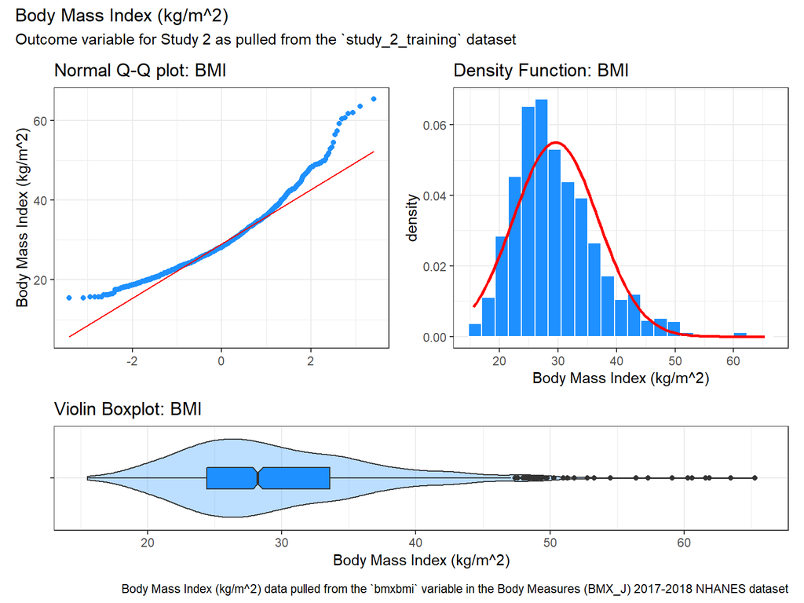

```r
viz1 <- ggplot(study_2_training, aes(x = "", y = bmxbmi)) +
  geom_violin(fill = "dodgerblue", alpha = 0.3) +
  geom_boxplot(width = 0.25, fill = "dodgerblue", notch = TRUE) +
  coord_flip() +
  labs(title = "Violin Boxplot: BMI", x = "", y = "Body Mass Index (kg/m^2)")

viz2 <- ggplot(study_2_training, aes(x = bmxbmi)) +
  geom_histogram(aes(y = stat(density)), bins = nclass.scott(study_2_training$bmxbmi), col = "white", fill = "dodgerblue") +
  stat_function(fun = dnorm, args = list(mean = mean(study_2_training$bmxbmi), sd = sd(study_2_training$bmxbmi)), col = "red", lwd = 1) +
  labs(title = "Density Function: BMI", x = "Body Mass Index (kg/m^2)")

viz3 <- ggplot(study_2_training, aes(sample = bmxbmi)) +
  geom_qq(col = "dodgerblue") +
  geom_qq_line(col = "red") +
  labs(title = "Normal Q-Q plot: BMI", x = "", y = "Body Mass Index (kg/m^2)")

(viz3 + viz2) / viz1 +
  plot_layout(heights = c(5,2)) +
  plot_annotation(title = "Body Mass Index (kg/m^2)",
                  subtitle = "Outcome variable for Study 2 as pulled from the `study_2_training` dataset",
                  caption = "Body Mass Index (kg/m^2) data pulled from the `bmxbmi` variable in the Body Measures (BMX_J) 2017-2018 NHANES dataset")
```

These results clearly indicate the presence of some right-skew, so we will examine some possible transformations of the outcome `bmxbmi` for this study.

Later, we’ll augment this initial look at the outcome data with a Box-Cox plot to suggest a potential transformation. Should you decide to make such a transformation, remember to return here to plot the results for your new and transformed outcome.

## 6.2 Numerical Summary of the Outcome

To assess the distribution of our outcome `bmxbmi` numerically, we will use the `favstats` function from the `mosaic` package as shown in the code below:

```r
favstats(~ bmxbmi, data = study_2_training)
```

|  | min | Q1 | median | Q3 | max | mean | sd | n | missing |
| --- | --- | --- | --- | --- | --- | --- | --- | --- | --- |
|  | 15.5 | 24.4 | 28.2 | 33.575 | 65.3 | 29.57955 | 7.248016 | 1550 | 0 |

As with our graphical summaries above, the numerical summary here also suggests some right-skew, as the median of the outcome is slightly smaller than the mean, albeit not by much, so a transformation of the outcome may or may not be necessary. We will create a boxCox plot after assessing the numerical summaries for the predictors below.

## 6.3 Numerical Summaries of the Predictors

To numerically assess the distributions of the predictor variables for this study, we will utilize the `inspect` function, as it provides an easy way to obtain the same stats the `favstats` function for all of variables in our data frame. The code below accomplishes this, and also omits the `seq` and `bmxbmi` variables, as we don’t need to see a summary for the IDs, and we already have our summary for the outcome variable above:

```r
study_2_training %>% select(-seqn, -bmxbmi) %>%
  mosaic::inspect()
```

```
categorical variables:
    name  class levels    n missing
1 dbq700 factor      5 1550       0
                                   distribution
1 Good (37.9%), Fair (28.3%) ...

quantitative variables:
         name   class  min     Q1 median    Q3    max      mean       sd    n
...1    lbxtc numeric 76.0 158.25  181.0 210.0  446.0 186.01677 42.16372 1550
...2    lbxtr numeric 10.0  60.00   91.0 133.0 1479.0 111.37677 90.94831 1550
...3   lbdhdd numeric 11.0  42.00   51.0  61.0  151.0  53.15097 14.75740 1550
...4 bmxwaist numeric 63.2  87.00   98.4 110.9  169.5  99.77426 17.43726 1550
     missing
...1       0
...2       0
...3       0
...4       0
```

## 6.4 `boxCox` function to assess need for transformation of our outcome

We can only use a `boxCox` approach here if the distribution of our outcome variable `bmxbmi` only includes strictly positive values. We can see from our numerical summary earlier that the minimum `bmxbmi` in our `study_2_training` sample is 15.5, so this has been confirmed. As such, the code below will generate an appropriate boxCox plot with the `boxCox` function for us to assess outcome transformations, and we will also confirm our plot’s results with the use of the `powerTransform` function, both of which are from the `car` package. In both cases, we will only use our outcome variable and our five predictor variables for generating the model:

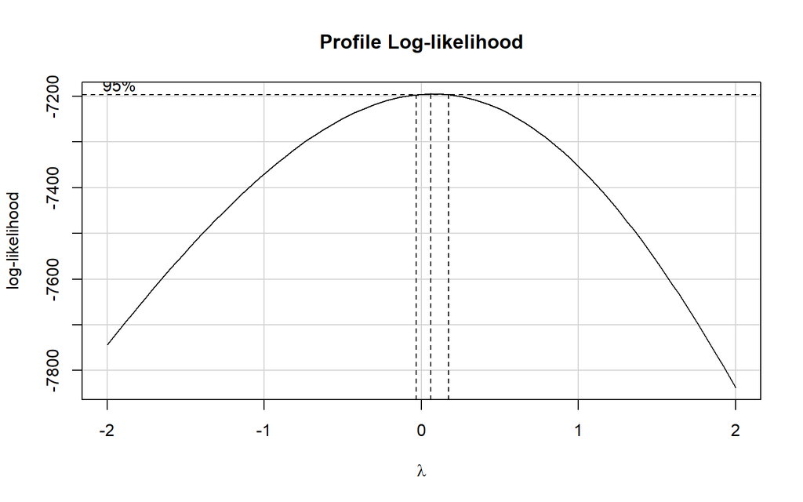

```r
model_temp <- lm(bmxbmi ~ lbxtc + lbxtr + lbdhdd + bmxwaist + dbq700,
                 data = study_2_training)

boxCox(model_temp)
```

```r
powerTransform(model_temp)
```

```
Estimated transformation parameter
        Y1
0.07055067
```

As the estimated power transformation is about 0.07, a natural logarithm transformation of `bmxbmi` looks as if it would be useful in this study. As such, we’re going to use the natural logarithm transformation for our outcome, and we will back-transform any predictions we make at the end of the study to ensure that the prediction error results are understandable. Additionally, we will add this transformation of `bmxbmi` to both our `study_2_training` and `study_2_test` tibbles, naming it `log_bmxbmi` for use in the rest of this analysis using the following code below:

```r
study_2_training = study_2_training %>%
  mutate(log_bmxbmi = log(bmxbmi))

study_2_test = study_2_test %>%
  mutate(log_bmxbmi = log(bmxbmi))
```

Lastly, before creating our Scatterplot Matrix below, we will create new graphical representations below to illustrate the distribution of our transformed outcome:

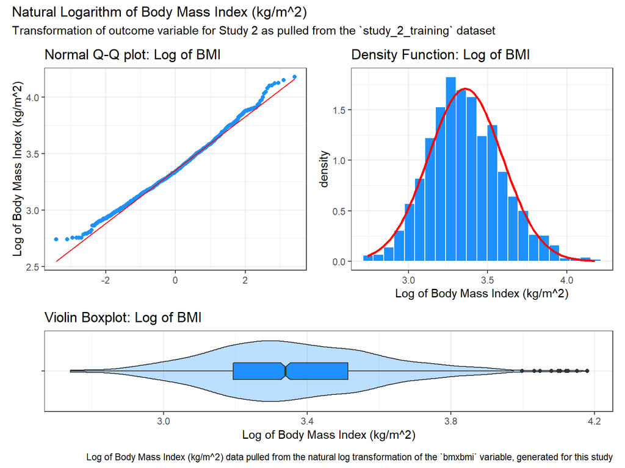

```r
viz1 <- ggplot(study_2_training, aes(x = "", y = log_bmxbmi)) +
  geom_violin(fill = "dodgerblue", alpha = 0.3) +
  geom_boxplot(width = 0.25, fill = "dodgerblue", notch = TRUE) +
  coord_flip() +
  labs(title = "Violin Boxplot: Log of BMI", x = "", y = "Log of Body Mass Index (kg/m^2)")

viz2 <- ggplot(study_2_training, aes(x = log_bmxbmi)) +
  geom_histogram(aes(y = stat(density)), bins = nclass.scott(study_2_training$bmxbmi), col = "white", fill = "dodgerblue") +
  stat_function(fun = dnorm, args = list(mean = mean(study_2_training$log_bmxbmi), sd = sd(study_2_training$log_bmxbmi)), col = "red", lwd = 1) +
  labs(title = "Density Function: Log of BMI", x = "Log of Body Mass Index (kg/m^2)")

viz3 <- ggplot(study_2_training, aes(sample = log_bmxbmi)) +
  geom_qq(col = "dodgerblue") +
  geom_qq_line(col = "red") +
  labs(title = "Normal Q-Q plot: Log of BMI", x = "", y = "Log of Body Mass Index (kg/m^2)")

(viz3 + viz2) / viz1 +
  plot_layout(heights = c(5,2)) +
  plot_annotation(title = "Natural Logarithm of Body Mass Index (kg/m^2)",
                  subtitle = "Transformation of outcome variable for Study 2 as pulled from the `study_2_training` dataset",
                  caption = "Log of Body Mass Index (kg/m^2) data pulled from the natural log transformation of the `bmxbmi` variable, generated for this study")
```

## 6.5 Scatterplot Matrix

In this section, we will build a scatterplot matrix that will allow us to illustrate the relationship between the natural logarithm transformation of our outcome variable `bmxbmi` and our predictor variables for this study. We will accomplish this by using the of the `ggpairs` function from the `GGally` package:

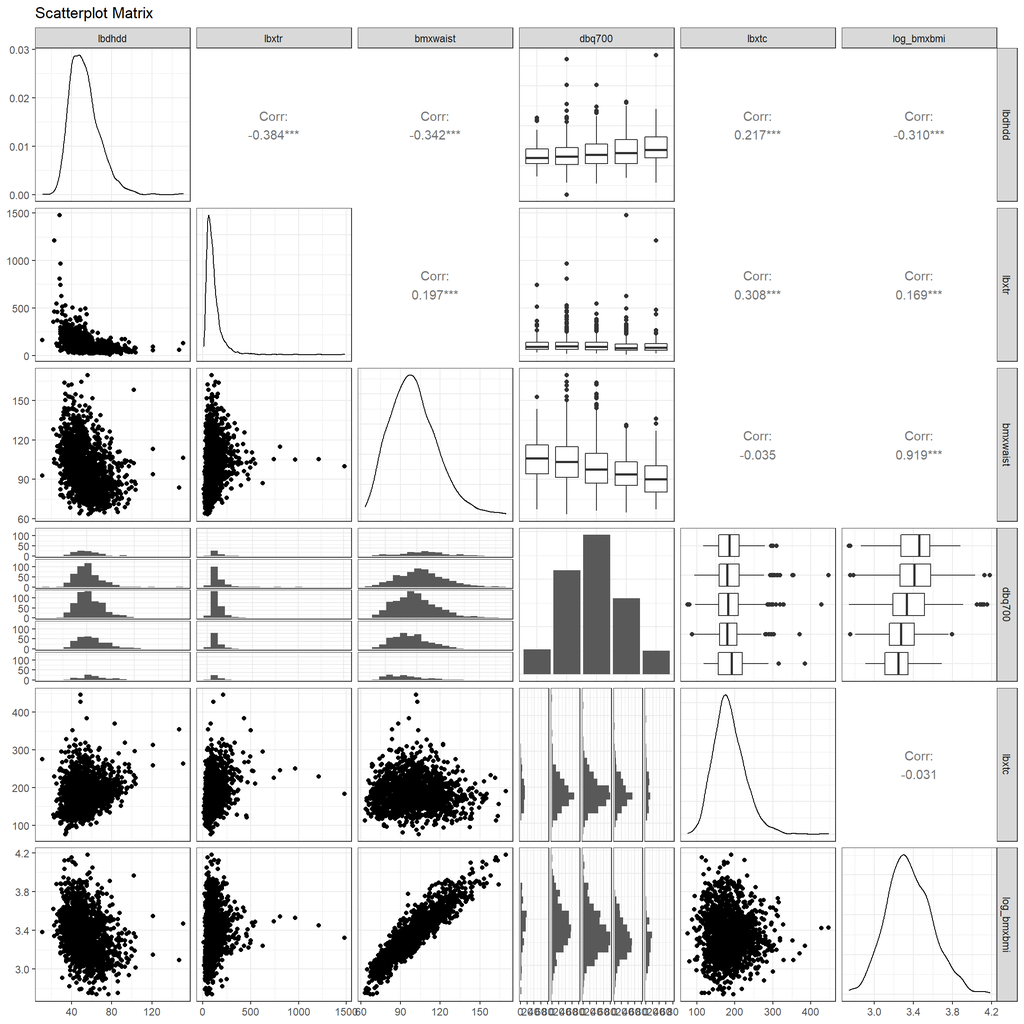

```r
study_2_training %>%
  select(lbdhdd, lbxtr, bmxwaist, dbq700, lbxtc, log_bmxbmi) %>%
  ggpairs(., title = "Scatterplot Matrix",
          lower = list(combo = wrap("facethist", bins = 20)))
```

The results of the scatteplot matrix above demonstrate that the log transformation of our outcome variable has weak correlations with our key predictor `lbxtc`, and two of our other predictors, `lbxtr` and `lbdhdd`, with correlations of -0.031, 0.169, and -0.310 each respectively. Conversely, the log of our outcome variable appears to correlate rather strongly with our last quantitative predictor, `bmxwaist`, with a correlation of 0.919.

Additionally, the distribution of the natural log of our outcome variable `log_bmxbmi` appears to follow a Normal distribution rather well, and the potential predictor `bmxwaist` also shows strong Normality, however the distributions for our other three quantitative predictors - `lbdhdd`, `lbxtr`, and our key predictor `lbxtc` do appear some detectable non-Normality.

Lastly, all of our quantitative predictors, as well as our transformed outcome, all seem to produce mostly decent normal distributions with our categorical variable `dbq700`, with Our three cholesterol variables, with `lbxtr` perhaps exhibiting the worst correlation with our categorical variable, which is also substantiated by examining the means vs medians for each categorical group of `dbq700` for `lbxtr` seen in the numerical summaries below, which include the numerical summaries produced using the `favstats` function for each variables as well as our transformed outcome variable for all the categories of `dbq700`.

```r
mosaic::favstats(log_bmxbmi ~ dbq700, data = study_2_training)
```

| dbq700 | min | Q1 | median | Q3 | max | mean | sd | n | missing |
| --- | --- | --- | --- | --- | --- | --- | --- | --- | --- |
| Poor | 2.740840 | 3.273364 | 3.459466 | 3.569533 | 3.879500 | 3.421722 | 0.2464671 | 105 | 0 |
| Fair | 2.753661 | 3.261935 | 3.407842 | 3.577948 | 4.178992 | 3.422492 | 0.2448660 | 439 | 0 |
| Good | 2.740840 | 3.190476 | 3.332205 | 3.511545 | 4.151040 | 3.358826 | 0.2328724 | 587 | 0 |
| Very Good | 2.753661 | 3.152736 | 3.273364 | 3.407842 | 3.793239 | 3.288568 | 0.1897758 | 320 | 0 |
| Excellent | 2.906901 | 3.109051 | 3.246491 | 3.342862 | 3.691376 | 3.243270 | 0.1869903 | 99 | 0 |

```r
mosaic::favstats(lbxtc ~ dbq700, data = study_2_training)
```

| dbq700 | min | Q1 | median | Q3 | max | mean | sd | n | missing |
| --- | --- | --- | --- | --- | --- | --- | --- | --- | --- |
| Poor | 117 | 158 | 186 | 212.00 | 310 | 188.9714 | 42.94148 | 105 | 0 |
| Fair | 94 | 159 | 180 | 211.00 | 446 | 185.7882 | 43.06545 | 439 | 0 |
| Good | 76 | 158 | 182 | 209.00 | 428 | 185.5315 | 42.01524 | 587 | 0 |
| Very Good | 88 | 160 | 180 | 206.25 | 370 | 184.2969 | 39.46209 | 320 | 0 |
| Excellent | 118 | 157 | 192 | 220.00 | 384 | 192.3333 | 46.56398 | 99 | 0 |

```r
mosaic::favstats(lbxtr ~ dbq700, data = study_2_training)
```

| dbq700 | min | Q1 | median | Q3 | max | mean | sd | n | missing |
| --- | --- | --- | --- | --- | --- | --- | --- | --- | --- |
| Poor | 31 | 63.0 | 94 | 140.00 | 743 | 117.5905 | 99.24278 | 105 | 0 |
| Fair | 16 | 65.0 | 97 | 138.00 | 967 | 118.2802 | 92.88470 | 439 | 0 |
| Good | 21 | 60.5 | 91 | 139.00 | 547 | 108.7581 | 67.63748 | 587 | 0 |
| Very Good | 10 | 55.0 | 79 | 120.25 | 1479 | 104.1437 | 105.43229 | 320 | 0 |
| Excellent | 24 | 55.5 | 82 | 125.00 | 1213 | 113.0808 | 133.11969 | 99 | 0 |

```r
mosaic::favstats(lbdhdd ~ dbq700, data = study_2_training)
```

| dbq700 | min | Q1 | median | Q3 | max | mean | sd | n | missing |
| --- | --- | --- | --- | --- | --- | --- | --- | --- | --- |
| Poor | 29 | 42 | 48 | 57.0 | 88 | 50.13333 | 11.86386 | 105 | 0 |
| Fair | 11 | 41 | 49 | 58.0 | 147 | 51.08884 | 14.16549 | 439 | 0 |
| Good | 22 | 42 | 51 | 61.5 | 121 | 53.00170 | 14.09482 | 587 | 0 |
| Very Good | 28 | 42 | 53 | 66.0 | 104 | 55.67813 | 15.77107 | 320 | 0 |
| Excellent | 23 | 48 | 56 | 69.0 | 151 | 58.21212 | 17.96781 | 99 | 0 |

```r
mosaic::favstats(bmxwaist ~ dbq700, data = study_2_training)
```

| dbq700 | min | Q1 | median | Q3 | max | mean | sd | n | missing |
| --- | --- | --- | --- | --- | --- | --- | --- | --- | --- |
| Poor | 67.2 | 94.300 | 106.0 | 116.100 | 152.8 | 104.98095 | 18.52809 | 105 | 0 |
| Fair | 63.2 | 91.450 | 103.2 | 114.850 | 169.5 | 104.11025 | 18.41007 | 439 | 0 |
| Good | 66.0 | 87.000 | 97.5 | 109.650 | 163.6 | 99.54855 | 17.32776 | 587 | 0 |
| Very Good | 64.6 | 85.375 | 93.9 | 103.375 | 131.5 | 94.94750 | 14.12230 | 320 | 0 |
| Excellent | 67.0 | 80.200 | 90.1 | 100.100 | 136.3 | 91.96465 | 15.19946 | 99 | 0 |

## 6.6 Collinearity Checking

The correlations in all of the cases specified above though are still rather small overall though, so we will proceed with this analysis, although in the future we may wish to consider different predictors that correlate more strongly with this outcome. To be on the safe side, we will perform a generalized VIF after fitting our “kitchen sink” model (i.e. the big model) below to be on the safe side regarding collinearity.

# 7 The Big Model

## 7.1 Fitting/Summarizing the Kitchen Sink model

For complete clarification, the “kitchen sink” or “big” model will predict the natural logarithm of `bmxbmi` by utilizing the predictors `lbxtc`, `lbxtr`, `lbdhdd`, `bmxwaist` and `dbq700`, and has been created and summarized with the code below:

```r
model_big <- lm(log(bmxbmi) ~ lbxtc + lbxtr + lbdhdd + bmxwaist + dbq700,
                data = study_2_training)
```

```r
summary(model_big)
```

```
Call:
lm(formula = log(bmxbmi) ~ lbxtc + lbxtr + lbdhdd + bmxwaist +
    dbq700, data = study_2_training)

Residuals:
     Min       1Q   Median       3Q      Max
-0.28100 -0.06008 -0.00293  0.05503  0.46246

Coefficients:
                  Estimate Std. Error t value Pr(>|t|)
(Intercept)      2.135e+00  2.322e-02  91.942   <2e-16 ***
lbxtc            3.422e-05  6.310e-05   0.542    0.588
lbxtr           -3.723e-05  3.099e-05  -1.201    0.230
lbdhdd           1.735e-05  1.939e-04   0.089    0.929
bmxwaist         1.223e-02  1.457e-04  83.911   <2e-16 ***
dbq700Fair       1.153e-02  9.992e-03   1.154    0.249
dbq700Good       3.268e-03  9.776e-03   0.334    0.738
dbq700Very Good -1.091e-02  1.045e-02  -1.043    0.297
dbq700Excellent -1.972e-02  1.304e-02  -1.512    0.131
---
Signif. codes:  0 '***' 0.001 '**' 0.01 '*' 0.05 '.' 0.1 ' ' 1

Residual standard error: 0.09192 on 1541 degrees of freedom
Multiple R-squared:  0.8457,    Adjusted R-squared:  0.8449
F-statistic:  1055 on 8 and 1541 DF,  p-value: < 2.2e-16
```

## 7.2 Effect Sizes: Coefficient Estimates

Now that we have defined our big model above with the code for `model_big` shown above, we can use the code below to generate a tidy that specifies the size and magnitude of all the “kitchen sink” model’s coefficients that also provides the estimated effect sizes with 90% confidence intervals:

```r
tidy(model_big, conf.int = TRUE, conf.level = 0.90) %>%
  select(term, estimate, std.error, conf.low, conf.high, p.value) %>%
  kable(dig = 6)
```

| term | estimate | std.error | conf.low | conf.high | p.value |
| --- | --- | --- | --- | --- | --- |
| (Intercept) | 2.135110 | 0.023222 | 2.096890 | 2.173330 | 0.000000 |
| lbxtc | 0.000034 | 0.000063 | -0.000070 | 0.000138 | 0.587650 |
| lbxtr | -0.000037 | 0.000031 | -0.000088 | 0.000014 | 0.229801 |
| lbdhdd | 0.000017 | 0.000194 | -0.000302 | 0.000337 | 0.928746 |
| bmxwaist | 0.012227 | 0.000146 | 0.011988 | 0.012467 | 0.000000 |
| dbq700Fair | 0.011534 | 0.009992 | -0.004910 | 0.027979 | 0.248515 |
| dbq700Good | 0.003268 | 0.009776 | -0.012822 | 0.019358 | 0.738226 |
| dbq700Very Good | -0.010906 | 0.010453 | -0.028110 | 0.006298 | 0.296958 |
| dbq700Excellent | -0.019718 | 0.013037 | -0.041175 | 0.001740 | 0.130635 |

It’s worth noting that the reason we specified 6 digits for output here was in order to ensure we got at least two significant figures in our coefficient and standard error estimates for all of the predictors in this model, and in order to do this we needed to go out to 6 decimal places.

## 7.3 Describing the Equation

Next, we will present the model as an equation by using the `extract_eq()` function from the `equatiomatic` package:

```r
extract_eq(model_big, use_coefs = TRUE, coef_digits = 6,
           terms_per_line = 3, wrap = TRUE, ital_vars = TRUE)
```

$$\begin{aligned}
\widehat{log(bmxbmi)} &= 2.13511 + 3.4e-05(lbxtc) - 3.7e-05(lbxtr)\ + \\
&\quad 1.7e-05(lbdhdd) + 0.012227(bmxwaist) + 0.011534(dbq700_{Fair})\ + \\
&\quad 0.003268(dbq700_{Good}) - 0.010906(dbq700_{Very\ Good}) - 0.019718(dbq700_{Excellent})
\end{aligned}$$

# 8 The Smaller Model

## 8.1 Backwards Stepwise Elimination

```r
step(model_big)
```

```
Start:  AIC=-7390.15
log(bmxbmi) ~ lbxtc + lbxtr + lbdhdd + bmxwaist + dbq700

           Df Sum of Sq    RSS     AIC
- lbdhdd    1     0.000 13.021 -7392.1
- lbxtc     1     0.002 13.023 -7391.9
- lbxtr     1     0.012 13.033 -7390.7
<none>                  13.021 -7390.1
- dbq700    4     0.133 13.154 -7382.4
- bmxwaist  1    59.495 72.516 -4730.4

Step:  AIC=-7392.14
log(bmxbmi) ~ lbxtc + lbxtr + bmxwaist + dbq700

           Df Sum of Sq    RSS     AIC
- lbxtc     1     0.003 13.024 -7393.8
- lbxtr     1     0.016 13.037 -7392.2
<none>                  13.021 -7392.1
- dbq700    4     0.133 13.154 -7384.4
- bmxwaist  1    63.598 76.619 -4647.1

Step:  AIC=-7393.75
log(bmxbmi) ~ lbxtr + bmxwaist + dbq700

           Df Sum of Sq    RSS     AIC
- lbxtr     1     0.013 13.038 -7394.2
<none>                  13.024 -7393.8
- dbq700    4     0.133 13.157 -7386.0
- bmxwaist  1    64.159 77.183 -4637.7

Step:  AIC=-7394.16
log(bmxbmi) ~ bmxwaist + dbq700

           Df Sum of Sq    RSS     AIC
<none>                  13.038 -7394.2
- dbq700    4     0.133 13.171 -7386.4
- bmxwaist  1    66.236 79.274 -4598.3
```

```
Call:
lm(formula = log(bmxbmi) ~ bmxwaist + dbq700, data = study_2_training)

Coefficients:
    (Intercept)         bmxwaist       dbq700Fair       dbq700Good
       2.142889         0.012182         0.011376         0.003279
dbq700Very Good  dbq700Excellent
      -0.010930        -0.019893
```

The backwards stepwise elimination approach suggests a model with `bmxwaist` and `dbq700`, but not `lbdhdd` or `lbxtr`, or our key predictor `lbxtc`. Since throwing out our key predictor would not make sense, we will use this last model that the backwards stepwise elimination approach suggests, but we will add our key predictor back into it.

## 8.2 Fitting the “small” model

Working from our conclusion from the backwards stepwise elimination above, we fit our new “small” model below with the following code:

```r
model_small <- lm(log(bmxbmi) ~ lbxtc + bmxwaist + dbq700, data = study_2_training)

summary(model_small)
```

```
Call:
lm(formula = log(bmxbmi) ~ lbxtc + bmxwaist + dbq700, data = study_2_training)

Residuals:
     Min       1Q   Median       3Q      Max
-0.27973 -0.06044 -0.00277  0.05435  0.46557

Coefficients:
                  Estimate Std. Error t value Pr(>|t|)
(Intercept)      2.141e+00  2.025e-02 105.736   <2e-16 ***
lbxtc            1.018e-05  5.549e-05   0.183    0.854
bmxwaist         1.218e-02  1.377e-04  88.491   <2e-16 ***
dbq700Fair       1.141e-02  9.988e-03   1.142    0.254
dbq700Good       3.319e-03  9.771e-03   0.340    0.734
dbq700Very Good -1.087e-02  1.043e-02  -1.042    0.298
dbq700Excellent -1.992e-02  1.300e-02  -1.532    0.126
---
Signif. codes:  0 '***' 0.001 '**' 0.01 '*' 0.05 '.' 0.1 ' ' 1

Residual standard error: 0.09192 on 1543 degrees of freedom
Multiple R-squared:  0.8455,    Adjusted R-squared:  0.8449
F-statistic:  1407 on 6 and 1543 DF,  p-value: < 2.2e-16
```

## 8.3 Effect Sizes: Coefficient Estimates

The size and magnitude of all of the coefficients will be specified with the code below, and an estimated effect size with 90% confidence intervals will also be provided:

```r
tidy(model_small, conf.int = TRUE, conf.level = 0.90) %>%
  select(term, estimate, std.error, conf.low, conf.high, p.value) %>%
  kable(dig = 4)
```

| term | estimate | std.error | conf.low | conf.high | p.value |
| --- | --- | --- | --- | --- | --- |
| (Intercept) | 2.1409 | 0.0202 | 2.1075 | 2.1742 | 0.0000 |
| lbxtc | 0.0000 | 0.0001 | -0.0001 | 0.0001 | 0.8544 |
| bmxwaist | 0.0122 | 0.0001 | 0.0120 | 0.0124 | 0.0000 |
| dbq700Fair | 0.0114 | 0.0100 | -0.0050 | 0.0278 | 0.2535 |
| dbq700Good | 0.0033 | 0.0098 | -0.0128 | 0.0194 | 0.7341 |
| dbq700Very Good | -0.0109 | 0.0104 | -0.0280 | 0.0063 | 0.2975 |
| dbq700Excellent | -0.0199 | 0.0130 | -0.0413 | 0.0015 | 0.1258 |

## 8.4 Small Model Regression Equation

As with the big model, we have once again used the `extract_eq()` function from the `equatiomatic` to visualize the equation for our small model below:

```r
extract_eq(model_small, use_coefs = TRUE, coef_digits = 4,
           terms_per_line = 3, wrap = TRUE, ital_vars = TRUE)
```

$$\begin{aligned}
\widehat{log(bmxbmi)} &= 2.1409 + 0(lbxtc) + 0.0122(bmxwaist)\ + \\
&\quad 0.0114(dbq700_{Fair}) + 0.0033(dbq700_{Good}) - 0.0109(dbq700_{Very\ Good})\ - \\
&\quad 0.0199(dbq700_{Excellent})
\end{aligned}$$

# 9 In-Sample Comparison

## 9.1 Quality of Fit

Now that we have our two models, we will utilize adjusted R<sup>2</sup>, the residual standard error, AIC and BIC to assess both of these models using in our training sample by using the following code:

```r
temp_a <- glance(model_big) %>%
  select(-logLik, -deviance) %>%
  round(digits = 3) %>%
  mutate(modelname = "big")

temp_b <- glance(model_small) %>%
  select(-logLik, -deviance) %>%
  round(digits = 3) %>%
  mutate(modelname = "small")

training_comp <- bind_rows(temp_a, temp_b) %>%
  select(modelname, nobs, df, AIC, BIC, everything())
```

```r
training_comp
```

| modelname | nobs | df | AIC | BIC | r.squared | adj.r.squared | sigma | statistic | p.value | df.residual |
| --- | --- | --- | --- | --- | --- | --- | --- | --- | --- | --- |
| big | 1550 | 8 | -2989.437 | -2935.976 | 0.846 | 0.845 | 0.092 | 1055.493 | 0 | 1541 |
| small | 1550 | 6 | -2991.485 | -2948.717 | 0.845 | 0.845 | 0.092 | 1407.054 | 0 | 1543 |

## 9.2 Assessing Assumptions

In the following section, we will run a set of residual plots for both of our models:

### 9.2.1 Residual Plots for the Big Model

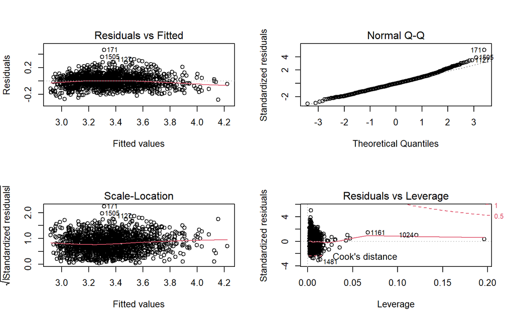

```r
par(mfrow = c(2,2)); plot(model_big); par(mfrow = c(1,1))
```

The most notable concern we have about these residuals is a potential issue with Normality, as our Normal Q-Q plot seems to have some rather high standardized residuals, with the most outlying point (171) appearing to be above 4 standardized residuals. To see if this is a problem, we will use the `outlierTest` function from the `car` package to test the most outlying point to see if it is indeed a concern:

```r
outlierTest(model_big)
```

```
    rstudent unadjusted p-value Bonferroni p
171 5.080446          4.225e-07   0.00065488
```

It’s worth mentioning that despite this Normality problem, we see no serious problems with the assumptions of linearity, we do not see any highly influential points in our big model in our Residuals vs Leverage plot, and there doesn’t appear to be an issue with constant variance either.

### 9.2.2 Residual Plots for the Small Model

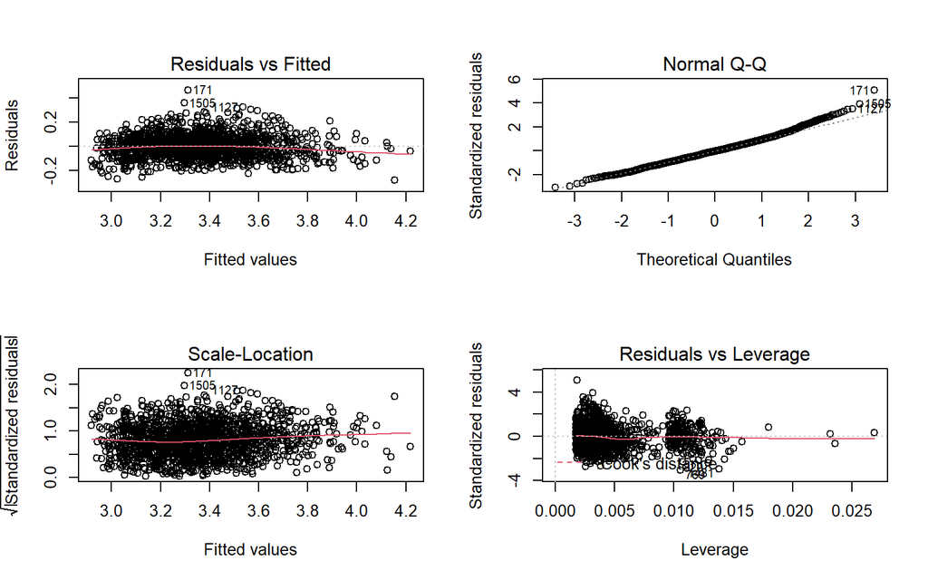

```r
par(mfrow = c(2,2)); plot(model_small); par(mfrow = c(1,1))
```

Once again, the most notable concern we have about these residuals is a potential issue with Normality, as our Normal Q-Q plot appears to be quite similar to that of our big model, and seems to have some rather high standardized residuals, with the most outlying point (171) appearing to be above 4 standardized residuals again. Just as last time, we will see if this is a problem by using the `outlierTest` function from the `car` package to test the most outlying point to see if it is indeed a concern:

```r
outlierTest(model_small)
```

```
    rstudent unadjusted p-value Bonferroni p
171 5.110605         3.6122e-07   0.00055989
```

It’s worth mentioning that despite this Normality problem, we once again see no serious problems with the assumptions of linearity, we do not see any highly influential points in our small model in our Residuals vs Leverage plot, and there doesn’t appear to be an issue with constant variance either.

### 9.2.3 Does collinearity have a meaningful impact?

Whenever an analysis is performed that fits a model or models with multiple predictors, it is usually wise to assess those models for any potential impact of collinearity. This can be accomplished by using the `vif` function from the `car` package, which as been done with the code below:

```r
car::vif(model_big)
```

```
             GVIF Df GVIF^(1/(2*Df))
lbxtc    1.297484  1        1.139072
lbxtr    1.456640  1        1.206913
lbdhdd   1.501660  1        1.225422
bmxwaist 1.183586  1        1.087927
dbq700   1.067528  4        1.008202
```

For any meaningful collinearity to be of concern to us, we would need to see a generalized variance inflation factor above 5 for a variable in a given model, and none of the generalized variance inflation factors for any of the variables in our big model even break a value of 2, so we shouldn’t be concerned about collinearity with our big model. Although our small model also has multiple predictors, we already know from the results above that it cannot be an issue either, as it is simply a subset of our big model, which we just established didn’t have any meaningful collinearity, so we know the small model should be fine as well.

## 9.3 Comparing the Models

Based on the training sample, my conclusions so far is to support the smaller model. It has (slightly) better performance on the fit quality measures, and each model shows no serious problems with regression assumptions.

# 10 Model Validation

Now, we will use our two regression models to predict the value of our outcome using the predictor values in the test sample. As mentioned when we determined our transformation for our outcome data, we will need to back-transform the predictions to the original units, in this case by using the `exp()` function, and we’ll need to compare our models to out of sample predictions to see which is better at predicting these out of sample values.

## 10.1 Calculating Prediction Errors

### 10.1.1 Big Model: Back-Transformation and Calculating Fits/Residuals

We’ll use the `augment` function from the `broom` package to help us here, and create `bmxbmi_fit` to hold the fitted values on the original `bmxbmi` scale after back-transformation (by using the `exp()` function to reverse the natural log transformation) and then `bmxbmi_res` to hold the residuals (prediction errors) we observe using the big model on the `study_2_test` data.

```r
aug_big <- augment(model_big, newdata = study_2_test) %>%
  mutate(mod_name = "big",
         bmxbmi_fit = exp(.fitted),
         bmxbmi_res = bmxbmi - bmxbmi_fit) %>%
  select(seqn, mod_name, bmxbmi, bmxbmi_fit, bmxbmi_res, everything())

head(aug_big,3)
```

| seqn | mod_name | bmxbmi | bmxbmi_fit | bmxbmi_res | lbxtc | lbxtr | lbdhdd | bmxwaist | dbq700 | log_bmxbmi | .fitted | .resid |
| --- | --- | --- | --- | --- | --- | --- | --- | --- | --- | --- | --- | --- |
| 93757 | big | 34.9 | 35.15614 | -0.2561438 | 204 | 172 | 48 | 116.4 | Poor | 3.552487 | 3.559799 | -0.007312561 |
| 93760 | big | 37.7 | 30.48714 | 7.2128556 | 213 | 176 | 41 | 103.8 | Fair | 3.629660 | 3.417305 | 0.212354994 |
| 93766 | big | 27.1 | 24.83400 | 2.2660004 | 254 | 209 | 50 | 87.0 | Fair | 3.299534 | 3.212214 | 0.087320062 |

### 10.1.2 Small Model: Back-Transformation and Calculating Fits/Residuals

We’ll do the same thing, but using the small model in the `study_2_test` data.

```r
aug_small <- augment(model_small, newdata = study_2_test) %>%
  mutate(mod_name = "small",
         bmxbmi_fit = exp(.fitted),
         bmxbmi_res = bmxbmi - bmxbmi_fit) %>%
  select(seqn, mod_name, bmxbmi, bmxbmi_fit, bmxbmi_res, everything())

head(aug_small,3)
```

| seqn | mod_name | bmxbmi | bmxbmi_fit | bmxbmi_res | lbxtc | lbxtr | lbdhdd | bmxwaist | dbq700 | log_bmxbmi | .fitted | .resid |
| --- | --- | --- | --- | --- | --- | --- | --- | --- | --- | --- | --- | --- |
| 93757 | small | 34.9 | 35.19791 | -0.2979106 | 204 | 172 | 48 | 116.4 | Poor | 3.552487 | 3.560987 | -0.008499894 |
| 93760 | small | 37.7 | 30.53853 | 7.1614731 | 213 | 176 | 41 | 103.8 | Fair | 3.629660 | 3.418989 | 0.210671031 |
| 93766 | small | 27.1 | 24.89685 | 2.2031508 | 254 | 209 | 50 | 87.0 | Fair | 3.299534 | 3.214741 | 0.084792473 |

### 10.1.3 Combining the Results

```r
test_comp <- union(aug_big, aug_small) %>%
  arrange(seqn, mod_name)

test_comp %>% head()
```

| seqn | mod_name | bmxbmi | bmxbmi_fit | bmxbmi_res | lbxtc | lbxtr | lbdhdd | bmxwaist | dbq700 | log_bmxbmi | .fitted | .resid |
| --- | --- | --- | --- | --- | --- | --- | --- | --- | --- | --- | --- | --- |
| 93757 | big | 34.9 | 35.15614 | -0.2561438 | 204 | 172 | 48 | 116.4 | Poor | 3.552487 | 3.559799 | -0.007312561 |
| 93757 | small | 34.9 | 35.19791 | -0.2979106 | 204 | 172 | 48 | 116.4 | Poor | 3.552487 | 3.560987 | -0.008499894 |
| 93760 | big | 37.7 | 30.48714 | 7.2128556 | 213 | 176 | 41 | 103.8 | Fair | 3.629660 | 3.417305 | 0.212354994 |
| 93760 | small | 37.7 | 30.53853 | 7.1614731 | 213 | 176 | 41 | 103.8 | Fair | 3.629660 | 3.418989 | 0.210671031 |
| 93766 | big | 27.1 | 24.83400 | 2.2660004 | 254 | 209 | 50 | 87.0 | Fair | 3.299534 | 3.212214 | 0.087320062 |
| 93766 | small | 27.1 | 24.89685 | 2.2031508 | 254 | 209 | 50 | 87.0 | Fair | 3.299534 | 3.214741 | 0.084792473 |

Given this `test_comp` tibble, including predictions and residuals from the kitchen sink model on our test data, we can now visualize the prediction errors from each model, proceed to summarize those errors across each model, and then identify the “worst fitting” subject for each model in the test sample.

We will perform all of these in the next few sections.

## 10.2 Visualizing the Predictions

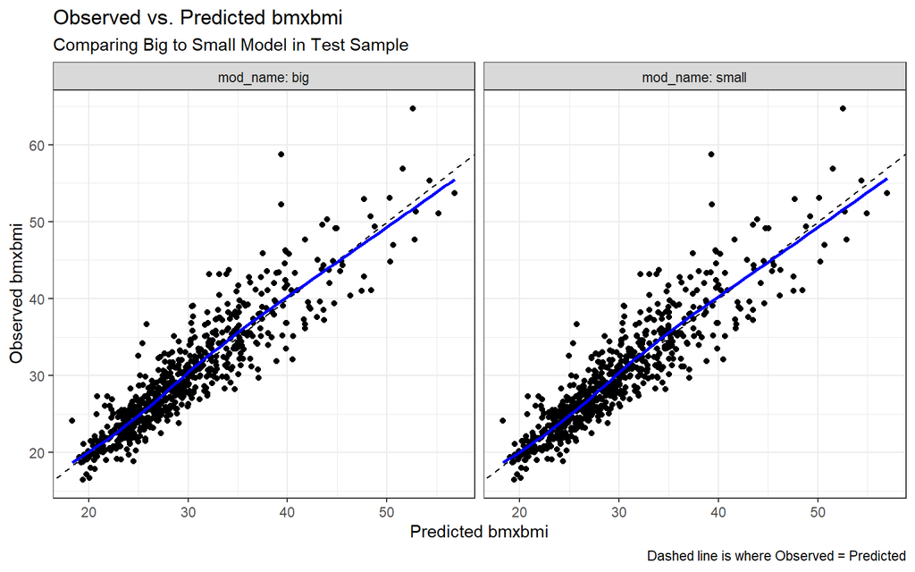

```r
ggplot(test_comp, aes(x = bmxbmi_fit, y = bmxbmi)) +
  geom_point() +
  geom_abline(slope = 1, intercept = 0, lty = "dashed") +
  geom_smooth(method = "loess", col = "blue", se = FALSE, formula = y ~ x) +
  facet_wrap( ~ mod_name, labeller = "label_both") +
  labs(x = "Predicted bmxbmi",
       y = "Observed bmxbmi",
       title = "Observed vs. Predicted bmxbmi",
       subtitle = "Comparing Big to Small Model in Test Sample",
       caption = "Dashed line is where Observed = Predicted")
```

The models seem to be making fairly similar errors to each other, as we really aren’t seeing much difference between the two models in terms of adherence of the points to the regression line.